# Case Study 1 Thundercats

# Beer:

Humans have been consuming alcohol in its various forms for millenia. Fermentation is an art that we have perfected as a species. Beer ddrinkers are notoriously picky about the type of beer they consume, many prefer lower alcohol content varieties becuase they prefer to drink for longer periods of time, others prefer a stronger brew and prefer to drink beer for its flavor content rather than its intoxicating effects. Other drinkers prefer both - a beer that is easy to drink (low ABV) but with more flavor/body (higher IBU).

### In which state can we find the strongest brew?

Strength of beer is usually characterized by the ABV (Alcohol Content By Volume)

By analyzing the distrubution of ABV by state, we will attempt to answer this important QOI

### Where is the beer most bitter?

Bitterness of beer is usually characterized by the IBU (International Bitterness Unit)

By analyzing the distrubution of IBU by state, we will attempt to answer this important QOI

### Data

To investiage these QOIs - we will use an observational study conducted across all 50 states (except North Dakota?) to rank 2305 indivdual brews on their strength and bitterness. Unfortunately - our dataset is rather sparsely populated for IBU data making any inferences on this variable subject to skepticism and further investigation.

### Breweries by State

[output not shown]

### By region?

[output not shown]

## NAs by column

Overall- the most represented (and potentially most popular) style of beer is the American IPA (making up roughly 20% of the overall study)

The state with the most beers sampled overall was Colorado. A state known for its liberal policies surrounding consumption of quasi-illicit substances.

## effect of all the missing IBU data?

[output not shown]

## summary stats by state

[output not shown]

```
Don't go to South Dakota if you like bitter beer, there may not be any....

If you prefer a nice mix of ABV/IBU - head west, friend, there's gold out there!
```

## most boozy beer state

Colorado - no surprise here. Colorado is known for its liberal policies surrounding consumption of alcohol and other substances - hence having a beer with the strength of the average glass of wine is not altogether unexpected.

Although - if you just want to go to a state and get drunk off of a variety of beers Kentucky may be your best bet with a median ABV > 0.06

## most bitter beer state

Oregon has the most bitter beer in the sample - the aptly named “Bitter Bitch Imperial IPA” clocking in at a whopping 138 IBU!

BUT the most bitter beer on average in the sample (based off of the median) would be Maine

## ABV Summary

[output not shown]

## scatter ABV/IBU Data

```
  SCatter/Regression shows a strong indication of a linear trend between ABV/IBU with higher values for IBU generally correlating to higher ABV content. Since so much of the IBU data is missing - we should impute the values for the missing IBU data with it's average by style
```

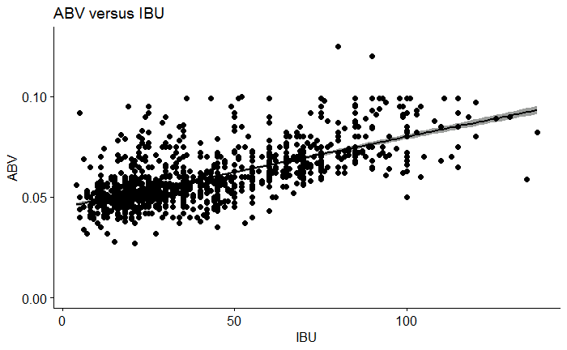

## Lets impute some values and re-run!

```
Imputing the average value by style allowed us to better analyze the trend between ABV/IBU in the absence of missing data. Most of the data that was missing is related to Ciders which should be excluded anyway since IBU is not a measure typically associated with that style of beverage.
```

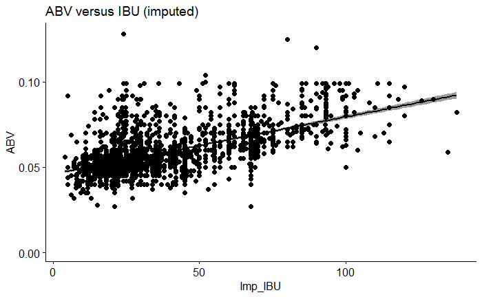